# Online_business

## Online Business Sales 2017-2019

### Dataset is actual sales from online store between 2017-2019

##### Background: The datasets are from a unnamed business' online retail sales for the period 2017-2019. 1st dataset shows individual orders, 2nd dataset shows aggregated monthly data.

#### Tasks:

##### 1. Loading data and cleaning data (if necessary)

##### 2. Exploratory data analysis (EDA)

##### 3. Data visualizations

```python
import pandas as pd
import matplotlib.pyplot as plt
import numpy as np
from matplotlib import font_manager
from scipy.stats import linregress
```

### 1. Loading and cleaning data

```python
products = pd.read_csv("OnlineBusinessSales2017-2019/productretailsales.csv")
monthly_data = pd.read_csv("OnlineBusinessSales2017-2019/businessretailsales.csv")
```

```python
# checking data types and looking for missing values in columns

products.info()
```

```
<class 'pandas.core.frame.DataFrame'>
RangeIndex: 1775 entries, 0 to 1774
Data columns (total 6 columns):
 #   Column           Non-Null Count  Dtype
---  ------           --------------  -----
 0   Product Type     1767 non-null   object
 1   Net Quantity     1775 non-null   int64
 2   Gross Sales      1775 non-null   float64
 3   Discounts        1775 non-null   float64
 4   Returns          1775 non-null   float64
 5   Total Net Sales  1775 non-null   float64
dtypes: float64(4), int64(1), object(1)
memory usage: 83.3+ KB
```

```python
# Determining how many missing values are in each column

products.isna().sum()
```

```
Product Type       8
Net Quantity       0
Gross Sales        0
Discounts          0
Returns            0
Total Net Sales    0
dtype: int64
```

There are 8 missing values in Product Type column. They will be replaced with "Unknown" to save sales data from missing.

```python
# Replacing missing values in Product Type column with "Unknown"

products["Product Type"] = products["Product Type"].fillna("Unknown")
```

```python
monthly_data.info()
```

```
<class 'pandas.core.frame.DataFrame'>
RangeIndex: 36 entries, 0 to 35
Data columns (total 9 columns):
 #   Column        Non-Null Count  Dtype
---  ------        --------------  -----
 0   Month         36 non-null     object
 1   Year          36 non-null     int64
 2   Total Orders  36 non-null     int64
 3   Gross Sales   36 non-null     float64
 4   Discounts     36 non-null     float64
 5   Returns       36 non-null     float64
 6   Net Sales     36 non-null     float64
 7   Shipping      36 non-null     float64
 8   Total Sales   36 non-null     float64
dtypes: float64(6), int64(2), object(1)
memory usage: 2.7+ KB
```

```python
monthly_data.isna().sum()
```

```
Month           0
Year            0
Total Orders    0
Gross Sales     0
Discounts       0
Returns         0
Net Sales       0
Shipping        0
Total Sales     0
dtype: int64
```

There are no missing values in monthly_data dataset. Data loading and cleaning is completed.

In Python there is a conventional way of naming columns - descriptive, lowercase, words seperated by underscores.

```python
# Renaming columns in both datasets

products.columns = [
    "product_type",
    "net_qty",
    "gross_sales",
    "discounts",
    "returns",
    "total_net_sales",
]
monthly_data.columns = [
    "month",
    "year",
    "total_orders",
    "gross_sales",
    "discounts",
    "returns",
    "net_sales",
    "shipping",
    "total_sales",
]
```

```python
# Adding year_month column for easier sorting

monthly_data["year_month"] = pd.to_datetime(
    monthly_data["year"].astype(str) + "-" + monthly_data["month"], format="%Y-%B"
)
monthly_data["year_month"] = monthly_data["year_month"].dt.strftime("%Y-%m")
```

### 2. Exploratory Data Analysis + 3. Data Visualizations

#### Having a look at Product data

```python
products.head(10)
```

|  | product_type | net_qty | gross_sales | discounts | returns | total_net_sales |
| --- | --- | --- | --- | --- | --- | --- |
| 0 | Art & Sculpture | 34 | 14935.0 | -594.00 | -1609.0 | 12732.00 |
| 1 | Basket | 13 | 3744.0 | -316.80 | 0.0 | 3427.20 |
| 2 | Basket | 12 | 3825.0 | -201.60 | -288.0 | 3335.40 |
| 3 | Basket | 17 | 3035.0 | -63.25 | 0.0 | 2971.75 |
| 4 | Art & Sculpture | 47 | 2696.8 | -44.16 | 0.0 | 2652.64 |
| 5 | Basket | 17 | 2695.0 | -52.50 | -110.0 | 2532.50 |
| 6 | Basket | 20 | 2310.0 | -66.00 | -110.0 | 2134.00 |
| 7 | Christmas | 90 | 2160.0 | -45.59 | 0.0 | 2114.41 |
| 8 | Art & Sculpture | 10 | 2250.0 | -180.00 | 0.0 | 2070.00 |
| 9 | Basket | 11 | 1925.0 | -17.50 | 0.0 | 1907.50 |

Each row in this dataset represents a transaction where a customer bought a certain quantity of a product type, and the transaction generated some gross sales, discounts, and returns. The row also includes the total net sales generated by the transaction.

```python
products.describe()
```

|  | net_qty | gross_sales | discounts | returns | total_net_sales |
| --- | --- | --- | --- | --- | --- |
| count | 1775.000000 | 1775.000000 | 1775.000000 | 1775.000000 | 1775.000000 |
| mean | 3.712676 | 199.671746 | -6.317623 | -5.385437 | 187.968687 |
| std | 6.243078 | 464.880638 | 20.903517 | 46.654269 | 414.547039 |
| min | -1.000000 | 0.000000 | -594.000000 | -1609.000000 | -106.250000 |
| 25% | 1.000000 | 48.000000 | -6.000000 | 0.000000 | 44.800000 |
| 50% | 2.000000 | 100.000000 | 0.000000 | 0.000000 | 96.000000 |
| 75% | 4.000000 | 185.500000 | 0.000000 | 0.000000 | 184.750000 |
| max | 96.000000 | 14935.000000 | 0.000000 | 0.000000 | 12732.000000 |

#### Key takeaways

1. Average quantity per order - 3.71.
2. Average gross sales per order - $ 199.67
3. Average discounts per order - $ 6.32
4. Average returns per order - $ 5.39
5. Average net sales per order - $ 187.97

### Popularity of ordered products

```python
# Popularity of ordered products by order count

popularity = products.groupby("product_type").size().sort_values(ascending=False)
popularity
```

```
product_type
Basket              551
Art & Sculpture     337
Jewelry             210
Kitchen             161
Home Decor          131
Christmas            73
Soapstone            67
Kids                 63
Accessories          39
Music                29
Fair Trade Gifts     28
Recycled Art         23
Furniture            16
Textiles             14
One-of-a-Kind        12
Skin Care            11
Unknown               8
Gift Baskets          1
Easter                1
dtype: int64
```

There are product types that are sold in very small quantities. Will group all orders which are less than 30 in one group, named "Others".

```python
popularity["Other"] = popularity[popularity < 30].sum()
popularity = popularity[popularity >= 30]
popularity
```

```
product_type
Basket             551
Art & Sculpture    337
Jewelry            210
Kitchen            161
Home Decor         131
Christmas           73
Soapstone           67
Kids                63
Accessories         39
Other              143
dtype: int64
```

```python
# Setting up a Style, Font and Colors for visualizations
plt.style.use("dark_background")
plt.rcParams["font.family"] = "Bebas Neue"
colors = [
    "#f72585",
    "#b5179e",
    "#7209b7",
    "#560bad",
    "#480ca8",
    "#3a0ca3",
    "#3f37c9",
    "#4361ee",
    "#4895ef",
    "#4cc9f0",
]
```

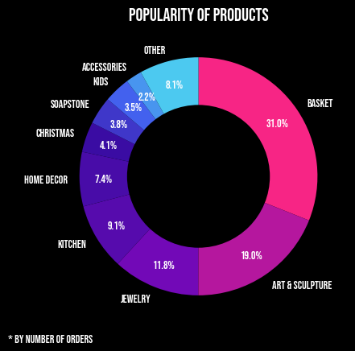

```python
plt.pie(
    popularity,
    labels=popularity.index,
    autopct="%1.1f%%",
    colors=colors,
    pctdistance=0.8,
    startangle=90,
    counterclock=False,
)
centre_circle = plt.Circle((0, 0), 0.60, fc="black")
fig = plt.gcf()
fig.gca().add_artist(centre_circle)
plt.title("Popularity of products", size=16)
plt.text(-1.6, -1.4, "* by number of orders")
plt.show()
```

```python
top_3 = (popularity[0:3].sum() / popularity.sum()) * 100
top_3 = str(round(top_3, 3)) + "%"
top_3
```

```
'61.859%'
```

Basket (31.0%), Art & Sculpture (19.0%) and Jewlery (11.8%) make up 61.859% of total number of orders.

- since these are popular products, business could try to increase their price to make the profit margin bigger.

```python
# Grouping by product type and adding new columns

products_grouped = products.groupby("product_type").sum().reset_index()
products_grouped["gross_sales_per_unit"] = (
    products_grouped["gross_sales"] / products_grouped["net_qty"]
)
products_grouped["net_sales_per_unit"] = (
    products_grouped["total_net_sales"] / products_grouped["net_qty"]
)
products_grouped["pct_lost"] = (
    100
    - (
        products_grouped["net_sales_per_unit"]
        / products_grouped["gross_sales_per_unit"]
    )
    * 100
)
products_grouped["return_rate"] = (
    (products_grouped["returns"] / products_grouped["gross_sales"]) * 100
).abs()
products_grouped
```

|  | product_type | net_qty | gross_sales | discounts | returns | total_net_sales | gross_sales_per_unit | net_sales_per_unit | pct_lost | return_rate |
| --- | --- | --- | --- | --- | --- | --- | --- | --- | --- | --- |
| 0 | Accessories | 84 | 3892.40 | -107.02 | 0.00 | 3785.38 | 46.338095 | 45.064048 | 2.749460 | 0.000000 |
| 1 | Art & Sculpture | 1427 | 90316.60 | -2955.82 | -2879.93 | 84480.85 | 63.291240 | 59.201717 | 6.461437 | 3.188705 |
| 2 | Basket | 1461 | 143815.50 | -4584.42 | -4439.69 | 134791.39 | 98.436345 | 92.259678 | 6.274783 | 3.087073 |
| 3 | Christmas | 575 | 15476.00 | -345.19 | -670.00 | 14460.81 | 26.914783 | 25.149235 | 6.559770 | 4.329284 |
| 4 | Easter | 1 | 38.00 | -3.80 | 0.00 | 34.20 | 38.000000 | 34.200000 | 10.000000 | 0.000000 |
| 5 | Fair Trade Gifts | 110 | 2258.00 | -53.33 | 0.00 | 2204.67 | 20.527273 | 20.042455 | 2.361825 | 0.000000 |
| 6 | Furniture | 27 | 2034.00 | -169.04 | 0.00 | 1864.96 | 75.333333 | 69.072593 | 8.310718 | 0.000000 |
| 7 | Gift Baskets | 1 | 19.50 | 0.00 | 0.00 | 19.50 | 19.500000 | 19.500000 | 0.000000 | 0.000000 |
| 8 | Home Decor | 404 | 27114.55 | -991.21 | -423.35 | 25699.99 | 67.115223 | 63.613837 | 5.216978 | 1.561339 |
| 9 | Jewelry | 991 | 31048.00 | -965.85 | -509.20 | 29572.95 | 31.329970 | 29.841524 | 4.750870 | 1.640041 |
| 10 | Kids | 140 | 3838.00 | -116.66 | 0.00 | 3721.34 | 27.414286 | 26.581000 | 3.039604 | 0.000000 |
| 11 | Kitchen | 809 | 16096.00 | -431.11 | -328.07 | 15336.82 | 19.896168 | 18.957750 | 4.716576 | 2.038208 |
| 12 | Music | 98 | 2643.50 | -82.19 | -142.41 | 2418.90 | 26.974490 | 24.682653 | 8.496312 | 5.387176 |
| 13 | One-of-a-Kind | 12 | 2180.00 | -71.99 | 0.00 | 2108.01 | 181.666667 | 175.667500 | 3.302294 | 0.000000 |
| 14 | Recycled Art | 99 | 3792.80 | -88.64 | 0.00 | 3704.16 | 38.311111 | 37.415758 | 2.337060 | 0.000000 |
| 15 | Skin Care | 101 | 2609.50 | -37.70 | 0.00 | 2571.80 | 25.836634 | 25.463366 | 1.444721 | 0.000000 |
| 16 | Soapstone | 199 | 4795.50 | -96.91 | -69.50 | 4629.09 | 24.097990 | 23.261759 | 3.470128 | 1.449275 |
| 17 | Textiles | 43 | 1889.00 | -112.90 | -97.00 | 1679.10 | 43.930233 | 39.048837 | 11.111699 | 5.134992 |
| 18 | Unknown | 8 | 560.50 | 0.00 | 0.00 | 560.50 | 70.062500 | 70.062500 | 0.000000 | 0.000000 |

#### Products sold

Showcase of products and their respective quantity sold.

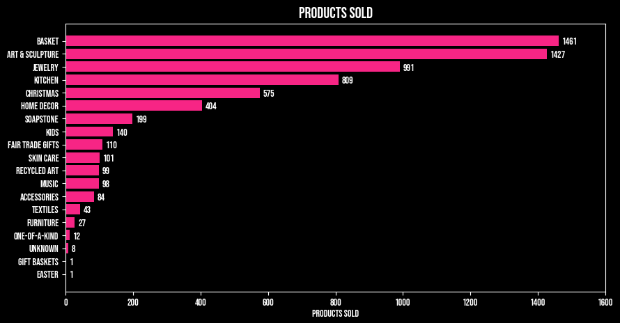

```python
products_grouped.sort_values("net_qty", ascending=False, inplace=True)
products_grouped.reset_index()
plt.figure(figsize=(10, 5))
plt.barh(products_grouped["product_type"], products_grouped["net_qty"], color=colors[0])
plt.gca().invert_yaxis()
plt.title("Products sold", size=16)
plt.xlabel("Products sold")
plt.xlim(0, 1600)
for i, v in enumerate(products_grouped["net_qty"]):
    plt.text(v + 10, i, v, ha="left", va="center")
plt.show()
```

Best selling products are:

1. Basket - 1461 units;
2. Art & Sculpture - 1427 units;
3. Jewlery - 991 units.

#### Most Valuable Products

Products sorted by price per unit to determine which products have the biggest impact on sales per one sold unit.

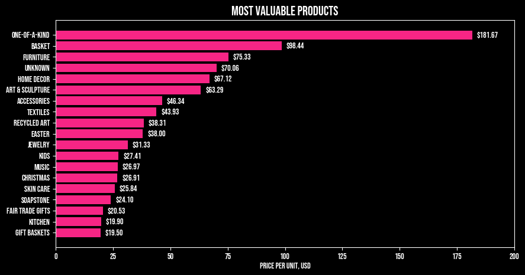

```python
products_grouped.sort_values("gross_sales_per_unit", ascending=False, inplace=True)
products_grouped.reset_index()
plt.figure(figsize=(10, 5))
plt.barh(
    products_grouped["product_type"],
    products_grouped["gross_sales_per_unit"],
    color=colors[0],
)
plt.gca().invert_yaxis()
plt.title("Most valuable products", size=16)
plt.xlabel("Price per unit, USD")
plt.xlim(0, 200)
for i, v in enumerate(products_grouped["gross_sales_per_unit"]):
    plt.text(v + 2, i, "${:,.2f}".format(v), ha="left", va="center")
plt.show()
```

Most value per sold unit:

1. One-of-a-kind - $ 181.67
2. Basket - $ 98.44
3. Furniture - $ 75.33
- Business could try to promote these products more in order to sell more units and gain bigger impact on sales.

#### Rate of returns

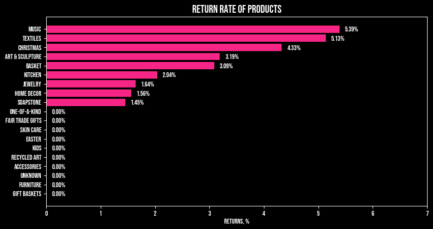

```python
products_grouped.sort_values("return_rate", ascending=False, inplace=True)
products_grouped.reset_index()
plt.figure(figsize=(10, 5))
plt.barh(
    products_grouped["product_type"],
    products_grouped["return_rate"],
    color=colors[0],
)
plt.gca().invert_yaxis()
plt.title("Return rate of products", size=16)
plt.xlabel("Returns, %")
plt.xlim(0, 7)
for i, v in enumerate(products_grouped["return_rate"]):
    plt.text(v + 0.1, i, "{:1.2f}%".format(v), ha="left", va="center")
plt.show()
```

Most frequently returned products:

1. Music - 5.39%
2. Textiles - 5.13%
3. Christmas - 4.33%
- Business should take a look at the possible causes of returning these products. (Quality issues, misleading advertising, etc)

#### Net Sales

Determining which products are impacting income the most.

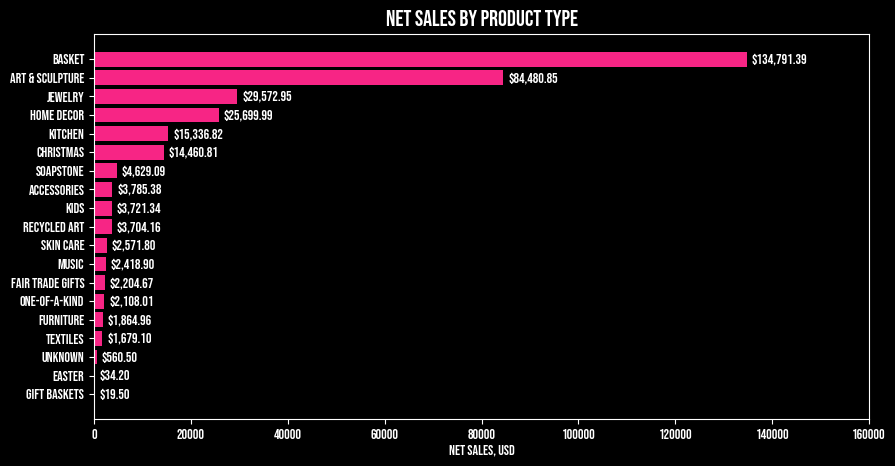

```python
products_grouped.sort_values("total_net_sales", ascending=False, inplace=True)
products_grouped.reset_index()
plt.figure(figsize=(10, 5))
plt.barh(
    products_grouped["product_type"],
    products_grouped["total_net_sales"],
    color=colors[0],
)
plt.gca().invert_yaxis()
plt.title("Net sales by product type", size=16)
plt.xlabel("Net sales, USD")
plt.xlim(0, 160000)
for i, v in enumerate(products_grouped["total_net_sales"]):
    plt.text(v + 1000, i, "${:,.2f}".format(v), ha="left", va="center")
plt.show()
```

Top products by net sales:

1. Basket - $ 134791.39
2. Art & Sculpture - $ 84480.85
3. Jewlery - $ 29572.95

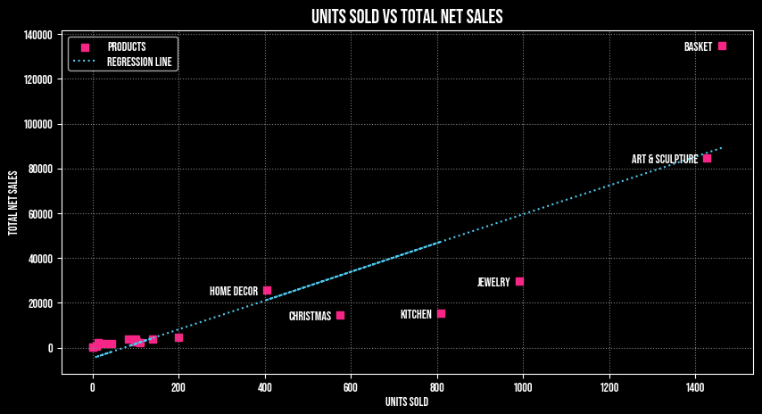

```python
fig, ax = plt.subplots(figsize=(10, 5))
ax.scatter(
    products_grouped["net_qty"],
    products_grouped["total_net_sales"],
    color=colors[0],
    marker="s",
    label="Products",
)
ax.set_xlabel("Units Sold")
ax.set_ylabel("Total Net Sales")
plt.title("Units Sold vs Total Net Sales", size=16)
plt.grid(color="grey", linestyle="dotted")

for i in range(products_grouped.shape[0]):
    if products_grouped["net_qty"][i] > 250:
        plt.text(
            x=products_grouped["net_qty"][i] - 20,
            y=products_grouped["total_net_sales"][i],
            s=products_grouped["product_type"][i],
            ha="right",
            va="center",
        )
# Calculate the regression line
x = products_grouped["net_qty"]
y = products_grouped["total_net_sales"]
slope, intercept, r_value, p_value, std_err = linregress(x, y)
line = slope * x + intercept

# Plot the regression line
plt.plot(x, line, color=colors[9], linestyle="dotted", label="Regression line")
plt.legend()
plt.show()
```

- Based on this scatter plot and regression line, we can see that such product types as Christmas, Kitchen, Jewelry, Art & Sculpture are under the regression line and it means that these product types are undervalued and could be sold for more.
- On the other hand - product type "Basket" is earning more in sales than it should. It should be exploited in order to earn even more.

## Yearly and monthly analysis

#### Having a look at monthly data

```python
monthly_data.head(10)
```

|  | month | year | total_orders | gross_sales | discounts | returns | net_sales | shipping | total_sales | year_month |
| --- | --- | --- | --- | --- | --- | --- | --- | --- | --- | --- |
| 0 | January | 2017 | 73 | 8861.5 | -129.40 | -448.45 | 8283.65 | 1088.30 | 9371.95 | 2017-01 |
| 1 | February | 2017 | 56 | 6908.5 | -104.70 | -416.20 | 6387.60 | 892.45 | 7280.05 | 2017-02 |
| 2 | March | 2017 | 60 | 5778.5 | -172.20 | -1017.20 | 4589.10 | 707.43 | 5296.53 | 2017-03 |
| 3 | April | 2017 | 70 | 8814.0 | -281.40 | 0.00 | 8532.60 | 1068.30 | 9600.90 | 2017-04 |
| 4 | May | 2017 | 54 | 6677.0 | -185.75 | -253.80 | 6237.45 | 866.46 | 7103.91 | 2017-05 |
| 5 | June | 2017 | 68 | 9621.5 | -234.45 | -17.50 | 9369.55 | 1204.32 | 10573.87 | 2017-06 |
| 6 | July | 2017 | 66 | 6480.0 | -51.50 | -469.20 | 5959.30 | 807.36 | 6766.66 | 2017-07 |
| 7 | August | 2017 | 55 | 8025.0 | -258.90 | -26.00 | 7740.10 | 843.46 | 8583.56 | 2017-08 |
| 8 | September | 2017 | 68 | 7075.0 | -61.70 | -281.00 | 6732.30 | 907.32 | 7639.62 | 2017-09 |
| 9 | October | 2017 | 59 | 5720.0 | -88.00 | -305.00 | 5327.00 | 695.42 | 6022.42 | 2017-10 |

Each row in this dataset represents a summary of sales data for a particular month and year. The row includes the total number of orders placed, as well as the gross sales, discounts, returns, and net sales for those orders. It also includes information on shipping and the total sales generated.

```python
monthly_data.describe()
```

|  | year | total_orders | gross_sales | discounts | returns | net_sales | shipping | total_sales |
| --- | --- | --- | --- | --- | --- | --- | --- | --- |
| count | 36.000000 | 36.000000 | 36.000000 | 36.000000 | 36.000000 | 36.000000 | 36.000000 | 36.000000 |
| mean | 2018.000000 | 97.138889 | 9844.926389 | -311.493889 | -474.958056 | 9058.474444 | 1579.391667 | 10637.941111 |
| std | 0.828079 | 57.458632 | 4936.386351 | 362.766989 | 488.820410 | 4497.185264 | 1011.170014 | 5475.621125 |
| min | 2017.000000 | 54.000000 | 5720.000000 | -2269.510000 | -1572.550000 | 4589.100000 | 695.420000 | 5296.530000 |
| 25% | 2017.000000 | 68.000000 | 7059.875000 | -300.375000 | -867.200000 | 6428.250000 | 1083.300000 | 7633.692500 |
| 50% | 2018.000000 | 82.500000 | 8850.500000 | -236.160000 | -299.875000 | 8076.430000 | 1341.650000 | 9404.405000 |
| 75% | 2019.000000 | 97.500000 | 10150.700000 | -169.487500 | -73.277500 | 9534.000000 | 1632.132500 | 11153.687500 |
| max | 2019.000000 | 342.000000 | 31183.900000 | -51.500000 | 0.000000 | 27603.210000 | 5703.250000 | 33306.460000 |

#### Key takeaways

1. Average orders per month - 97.14. (min - 54, max - 342)
2. Average gross sales per month - 9844.93 USD. (min - 5720.00 USD, max - 31183.90 USD)
3. Average discounts per month - 311.49 USD. (min - 51.50 USD, max - 2269.51 USD)
4. Average returns per month - 474.96 USD. (min - 0.00 USD, max - 1572.55 USD)
5. Average net sales per month - 9058.47 USD. (min - 4589.10 USD, max - 27603.21 USD)
6. Average shipping sales per month - 1579.39 USD. (min - 695.42 USD, max - 5703.25 USD)
7. Average total sales per month - 10637.94 USD. (min - 5296.53 USD, max - 33306.46 USD)

### Yearly Analysis

```python
# Grouping data by year

monthly_data_grouped = monthly_data.groupby(monthly_data["year"]).sum()
monthly_data_grouped
```

| year | total_orders | gross_sales | discounts | returns | net_sales | shipping | total_sales |
| --- | --- | --- | --- | --- | --- | --- | --- |
| 2017 | 836 | 97342.05 | -1849.15 | -3972.40 | 91520.50 | 11976.77 | 103497.27 |
| 2018 | 1141 | 113313.15 | -3112.39 | -5412.58 | 104788.18 | 18780.10 | 123568.28 |
| 2019 | 1520 | 143762.15 | -6252.24 | -7713.51 | 129796.40 | 26101.23 | 155900.33 |

```python
TOTAL_SALES = monthly_data_grouped["total_sales"].sum()
TOTAL_SALES
```

```
382965.88
```

During the 2017-2019 period this Online Business managed to achieve 382965.88 $ in total sales.

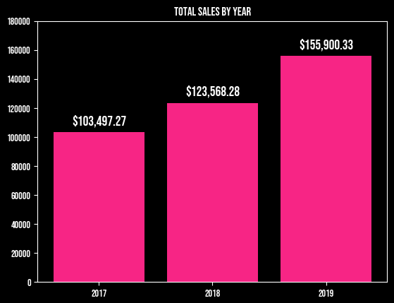

```python
labels = ["2017", "2018", "2019"]

# create a bar chart
fig, ax = plt.subplots()
ax.bar(labels, monthly_data_grouped["total_sales"], color=colors[0])
plt.ylim(0, 180000)
plt.title("Total sales by year")
# add y-axis values on top of each bar
for i, v in enumerate(monthly_data_grouped["total_sales"]):
    ax.text(i, v + 5000, "${:,.2f}".format(v), ha="center", size=14)

plt.show()
```

- Based on these 3 years, we can see that this Online Business is increasing sales each year and there is no reason to think that it will change in next years.

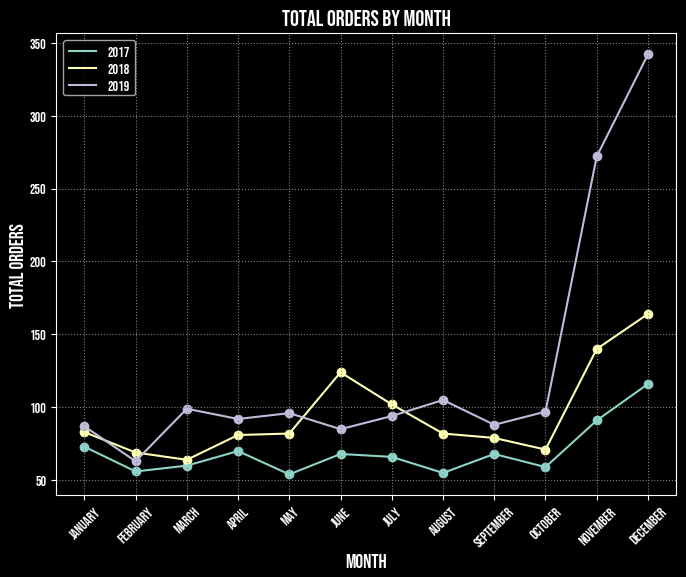

```python
years = monthly_data.groupby(monthly_data["year"])
fig, ax = plt.subplots(figsize=(8, 6))
for month, year in years:
    ax.plot(year["month"], year["total_orders"], label=month, lw=1.5)
    ax.scatter(year["month"], year["total_orders"])
ax.set_title("Total orders by month", size=16)
ax.set_xlabel("Month", size=14)
plt.grid(color="grey", linestyle="dotted")
plt.xticks(rotation=45)
ax.set_ylabel("Total orders", size=14)

ax.legend()
plt.savefig("Python2.png", dpi=200)
plt.show()
```

There is a noticable pattern - in each years November and December total orders increase. Looking at product types that are being sold, it could be explained by the purchases for Christmas gifts.

### Monthly Analysis

```python
monthly_data["MoM_orders"] = monthly_data["total_orders"].pct_change() * 100
monthly_data["MoM_gross_sales"] = monthly_data["gross_sales"].pct_change() * 100
monthly_data["MoM_net_sales"] = monthly_data["net_sales"].pct_change() * 100
monthly_data["MoM_total_sales"] = monthly_data["total_sales"].pct_change() * 100
monthly_data["orders_run_total"] = monthly_data["total_orders"].cumsum()
monthly_data["running_total_sales"] = monthly_data["total_sales"].cumsum()
monthly_data
```

|  | month | year | total_orders | gross_sales | discounts | returns | net_sales | shipping | total_sales | year_month | MoM_orders | MoM_gross_sales | MoM_net_sales | MoM_total_sales | orders_run_total | running_total_sales |
| --- | --- | --- | --- | --- | --- | --- | --- | --- | --- | --- | --- | --- | --- | --- | --- | --- |
| 0 | January | 2017 | 73 | 8861.50 | -129.40 | -448.45 | 8283.65 | 1088.30 | 9371.95 | 2017-01 | NaN | NaN | NaN | NaN | 73 | 9371.95 |
| 1 | February | 2017 | 56 | 6908.50 | -104.70 | -416.20 | 6387.60 | 892.45 | 7280.05 | 2017-02 | -23.287671 | -22.039158 | -22.889065 | -22.320862 | 129 | 16652.00 |
| 2 | March | 2017 | 60 | 5778.50 | -172.20 | -1017.20 | 4589.10 | 707.43 | 5296.53 | 2017-03 | 7.142857 | -16.356662 | -28.156115 | -27.245967 | 189 | 21948.53 |
| 3 | April | 2017 | 70 | 8814.00 | -281.40 | 0.00 | 8532.60 | 1068.30 | 9600.90 | 2017-04 | 16.666667 | 52.530934 | 85.931882 | 81.267736 | 259 | 31549.43 |
| 4 | May | 2017 | 54 | 6677.00 | -185.75 | -253.80 | 6237.45 | 866.46 | 7103.91 | 2017-05 | -22.857143 | -24.245518 | -26.898601 | -26.007874 | 313 | 38653.34 |
| 5 | June | 2017 | 68 | 9621.50 | -234.45 | -17.50 | 9369.55 | 1204.32 | 10573.87 | 2017-06 | 25.925926 | 44.099146 | 50.214431 | 48.845776 | 381 | 49227.21 |
| 6 | July | 2017 | 66 | 6480.00 | -51.50 | -469.20 | 5959.30 | 807.36 | 6766.66 | 2017-07 | -2.941176 | -32.650834 | -36.397159 | -36.005833 | 447 | 55993.87 |
| 7 | August | 2017 | 55 | 8025.00 | -258.90 | -26.00 | 7740.10 | 843.46 | 8583.56 | 2017-08 | -16.666667 | 23.842593 | 29.882704 | 26.850765 | 502 | 64577.43 |
| 8 | September | 2017 | 68 | 7075.00 | -61.70 | -281.00 | 6732.30 | 907.32 | 7639.62 | 2017-09 | 23.636364 | -11.838006 | -13.020504 | -10.997069 | 570 | 72217.05 |
| 9 | October | 2017 | 59 | 5720.00 | -88.00 | -305.00 | 5327.00 | 695.42 | 6022.42 | 2017-10 | -13.235294 | -19.151943 | -20.873996 | -21.168592 | 629 | 78239.47 |
| 10 | November | 2017 | 91 | 13025.00 | -131.30 | -323.85 | 12569.85 | 1555.10 | 14124.95 | 2017-11 | 54.237288 | 127.709790 | 135.964896 | 134.539438 | 720 | 92364.42 |
| 11 | December | 2017 | 116 | 10356.05 | -149.85 | -414.20 | 9792.00 | 1340.85 | 11132.85 | 2017-12 | 27.472527 | -20.490979 | -22.099309 | -21.183084 | 836 | 103497.27 |
| 12 | January | 2018 | 83 | 8923.00 | -217.10 | -26.25 | 8679.65 | 1180.18 | 9859.83 | 2018-01 | -28.448276 | -13.837805 | -11.359783 | -11.434808 | 919 | 113357.10 |
| 13 | February | 2018 | 69 | 6529.20 | -161.35 | -118.15 | 6249.70 | 908.91 | 7158.61 | 2018-02 | -16.867470 | -26.827300 | -27.995945 | -27.396213 | 988 | 120515.71 |
| 14 | March | 2018 | 64 | 7442.70 | -226.82 | -8.80 | 7207.08 | 1226.92 | 8434.00 | 2018-03 | -7.246377 | 13.990994 | 15.318815 | 17.816168 | 1052 | 128949.71 |
| 15 | April | 2018 | 81 | 9406.35 | -232.28 | -40.00 | 9134.07 | 1387.56 | 10521.63 | 2018-04 | 26.562500 | 26.383570 | 26.737458 | 24.752549 | 1133 | 139471.34 |
| 16 | May | 2018 | 82 | 7493.90 | -221.25 | -1448.02 | 5824.63 | 1234.95 | 7059.58 | 2018-05 | 1.234568 | -20.331478 | -36.231822 | -32.904122 | 1215 | 146530.92 |
| 17 | June | 2018 | 124 | 13260.80 | -335.40 | -1506.53 | 11418.87 | 2124.49 | 13543.36 | 2018-06 | 51.219512 | 76.954590 | 96.044556 | 91.843707 | 1339 | 160074.28 |
| 18 | July | 2018 | 102 | 9274.95 | -237.87 | -689.98 | 8347.10 | 1627.03 | 9974.13 | 2018-07 | -17.741935 | -30.057387 | -26.900823 | -26.354095 | 1441 | 170048.41 |
| 19 | August | 2018 | 82 | 7698.70 | -140.57 | -197.35 | 7360.78 | 1404.03 | 8764.81 | 2018-08 | -19.607843 | -16.994701 | -11.816319 | -12.124566 | 1523 | 178813.22 |
| 20 | September | 2018 | 79 | 10582.85 | -276.15 | 0.00 | 10306.70 | 1634.33 | 11941.03 | 2018-09 | -3.658537 | 37.462818 | 40.021846 | 36.238321 | 1602 | 190754.25 |
| 21 | October | 2018 | 71 | 7014.50 | -277.95 | -294.75 | 6441.80 | 1262.45 | 7704.25 | 2018-10 | -10.126582 | -33.718233 | -37.498908 | -35.480859 | 1673 | 198458.50 |
| 22 | November | 2018 | 140 | 12002.70 | -414.45 | -154.40 | 11433.85 | 2237.05 | 13670.90 | 2018-11 | 97.183099 | 71.112695 | 77.494644 | 77.446215 | 1813 | 212129.40 |
| 23 | December | 2018 | 164 | 13683.50 | -371.20 | -928.35 | 12383.95 | 2552.20 | 14936.15 | 2018-12 | 17.142857 | 14.003516 | 8.309537 | 9.255060 | 1977 | 227065.55 |
| 24 | January | 2019 | 87 | 7811.75 | -261.97 | -1250.35 | 6299.43 | 1313.78 | 7615.91 | 2019-01 | -46.951220 | -42.911170 | -49.132304 | -49.010220 | 2064 | 234681.46 |
| 25 | February | 2019 | 63 | 6523.70 | -288.70 | -38.70 | 6196.30 | 1121.85 | 7318.15 | 2019-02 | -27.586207 | -16.488623 | -1.637132 | -3.909710 | 2127 | 241999.61 |
| 26 | March | 2019 | 99 | 13075.50 | -439.85 | -981.00 | 11654.65 | 2115.10 | 13769.75 | 2019-03 | 57.142857 | 100.430737 | 88.090473 | 88.158893 | 2226 | 255769.36 |
| 27 | April | 2019 | 92 | 6977.00 | -285.40 | -10.00 | 6681.60 | 1342.45 | 8024.05 | 2019-04 | -7.070707 | -46.640664 | -42.670093 | -41.726974 | 2318 | 263793.41 |
| 28 | May | 2019 | 96 | 10082.25 | -460.90 | -173.35 | 9448.00 | 1768.20 | 11216.20 | 2019-05 | 4.347826 | 44.506951 | 41.403257 | 39.782280 | 2414 | 275009.61 |
| 29 | June | 2019 | 85 | 7321.75 | -186.02 | -165.40 | 6970.33 | 1356.80 | 8327.13 | 2019-06 | -11.458333 | -27.379801 | -26.224280 | -25.758011 | 2499 | 283336.74 |
| 30 | July | 2019 | 94 | 9739.20 | -447.07 | -908.75 | 8383.38 | 1631.40 | 10014.78 | 2019-07 | 10.588235 | 33.017380 | 20.272354 | 20.266887 | 2593 | 293351.52 |
| 31 | August | 2019 | 105 | 8839.50 | -201.67 | -84.37 | 8553.46 | 1724.75 | 10278.21 | 2019-08 | 11.702128 | -9.237925 | 2.028776 | 2.630412 | 2698 | 303629.73 |
| 32 | September | 2019 | 88 | 9077.45 | -354.89 | -853.35 | 7869.21 | 1567.65 | 9436.86 | 2019-09 | -16.190476 | 2.691894 | -7.999687 | -8.185764 | 2786 | 313066.59 |
| 33 | October | 2019 | 97 | 9132.25 | -279.42 | -1572.55 | 7280.28 | 1631.25 | 8911.53 | 2019-10 | 10.227273 | 0.603694 | -7.483979 | -5.566788 | 2883 | 321978.12 |
| 34 | November | 2019 | 272 | 23997.90 | -776.84 | -364.51 | 22856.55 | 4824.75 | 27681.30 | 2019-11 | 180.412371 | 162.781899 | 213.951524 | 210.623428 | 3155 | 349659.42 |
| 35 | December | 2019 | 342 | 31183.90 | -2269.51 | -1311.18 | 27603.21 | 5703.25 | 33306.46 | 2019-12 | 25.735294 | 29.944287 | 20.767176 | 20.321155 | 3497 | 382965.88 |

##### Total Orders by Month

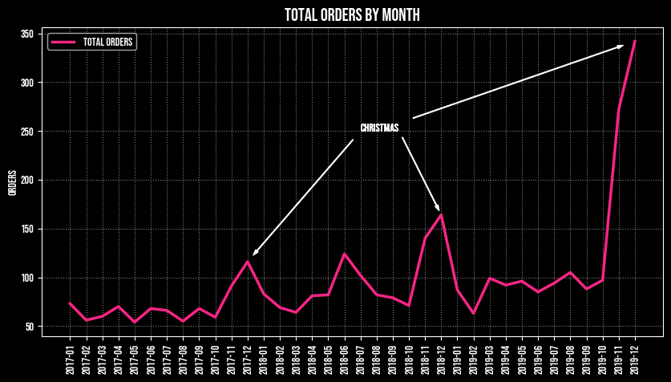

```python
plt.figure(figsize=(10, 5))
plt.plot(
    monthly_data["year_month"],
    monthly_data["total_orders"],
    label="Total Orders",
    lw=2.5,
    color=colors[0],
)
plt.xticks(rotation=90, fontname="Bebas Neue")
plt.yticks(fontname="Bebas Neue")
plt.title("Total orders by month", fontname="Bebas Neue", size=16)
plt.grid(color="grey", linestyle="dotted")
plt.ylabel("Orders")
plt.annotate(
    "Christmas",
    (monthly_data["year_month"][11], monthly_data["total_orders"][11]),
    ("2018-07", 250),
    arrowprops=dict(facecolor="w", shrink=0.05, width=0.5, headlength=5, headwidth=3),
    color="w",
    size=10,
)
plt.annotate(
    "Christmas",
    (monthly_data["year_month"][23], monthly_data["total_orders"][23]),
    ("2018-07", 250),
    arrowprops=dict(facecolor="w", shrink=0.05, width=0.5, headlength=5, headwidth=3),
    color="w",
    size=10,
)
plt.annotate(
    "Christmas",
    (monthly_data["year_month"][35], monthly_data["total_orders"][35]),
    ("2018-07", 250),
    arrowprops=dict(facecolor="w", shrink=0.05, width=0.5, headlength=5, headwidth=3),
    color="w",
    size=10,
)
plt.legend()
plt.show()
```

- There are significant increases in number of orders during the November and December each year. Reason: Christmas shopping for gifts.
- There is also a significant increase in June of 2018. Possible reasons: Sales, Promotions of products, etc (Need more data and context to give data-driven answer.)

#### Cumulative Sum of Orders

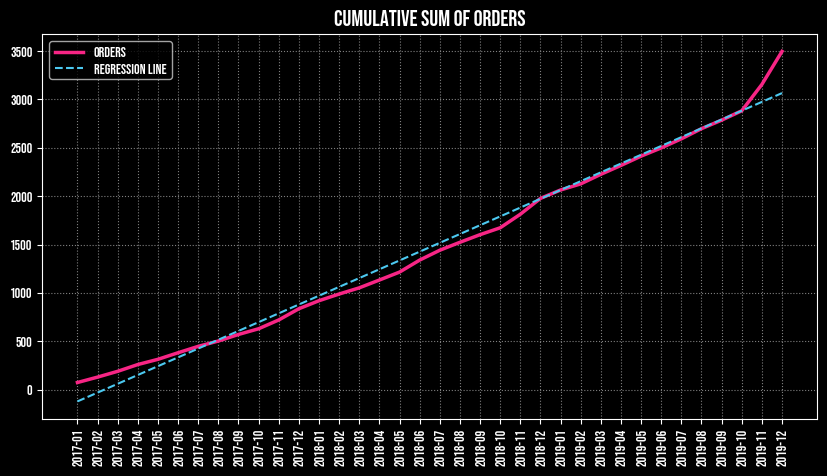

```python
plt.figure(figsize=(10, 5))
plt.plot(
    monthly_data["year_month"],
    monthly_data["orders_run_total"],
    label="Orders",
    lw=2.5,
    color=colors[0],
)
plt.xticks(rotation=90, fontname="Bebas Neue")
plt.yticks(fontname="Bebas Neue")
plt.title("Cumulative Sum of Orders", fontname="Bebas Neue", size=16)
plt.grid(color="grey", linestyle="dotted")
# Calculate the regression line
x = np.array(range(len(monthly_data)))
y = monthly_data["orders_run_total"]
slope, intercept, r_value, p_value, std_err = linregress(x, y)
line = slope * x + intercept

# Plot the regression line
plt.plot(x, line, color=colors[9], linestyle="--", label="Regression line")
plt.legend()
plt.show()
```

```python
# Getting the equation of the regression line and 'predicting' how many orders could be sold by the end of 2022

print(f"Regression line equation: y = {slope:.2f}x + {intercept:.2f}")
# Calculate the predicted y value for December 2022
x_dec_2022 = len(monthly_data) + 35  # assuming the last data point is December 2019
y_dec_2022 = slope * x_dec_2022 + intercept

# Print the predicted y value for December 2022
print(f"Predicted cumulative sum of orders for December 2022: {y_dec_2022:.0f}")
```

```
Regression line equation: y = 91.09x + -122.28
Predicted cumulative sum of orders for December 2022: 6345
```

By having a look at the cumulative sum of orders and creating a regression line to fit data the best, we could assume that if there are no significant changes in business, orders 3 years later (Dec 2022) would be around 6345.

#### Total Sales by Month

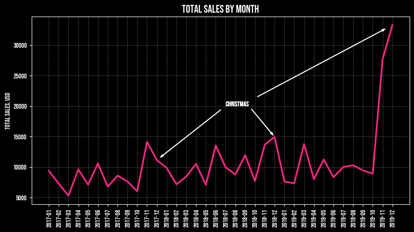

```python
plt.figure(figsize=(10, 5))
plt.plot(
    monthly_data["year_month"], monthly_data["total_sales"], lw=2.5, color=colors[0]
)
plt.xticks(rotation=90, fontname="Bebas Neue")
plt.yticks(fontname="Bebas Neue")
plt.title("Total sales by month", fontname="Bebas Neue", size=16)
plt.grid(color="grey", linestyle="dotted")
plt.ylabel("Total sales, USD")
plt.annotate(
    "Christmas",
    (monthly_data["year_month"][11], monthly_data["total_sales"][11]),
    ("2018-07", 20000),
    arrowprops=dict(facecolor="w", shrink=0.05, width=0.5, headlength=5, headwidth=3),
    color="w",
    size=10,
)
plt.annotate(
    "Christmas",
    (monthly_data["year_month"][23], monthly_data["total_sales"][23]),
    ("2018-07", 20000),
    arrowprops=dict(facecolor="w", shrink=0.05, width=0.5, headlength=5, headwidth=3),
    color="w",
    size=10,
)
plt.annotate(
    "Christmas",
    (monthly_data["year_month"][35], monthly_data["total_sales"][35]),
    ("2018-07", 20000),
    arrowprops=dict(facecolor="w", shrink=0.05, width=0.5, headlength=5, headwidth=3),
    color="w",
    size=10,
)
plt.show()
```

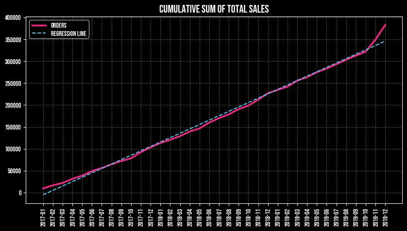

```python
plt.figure(figsize=(10, 5))
plt.plot(
    monthly_data["year_month"],
    monthly_data["running_total_sales"],
    label="Orders",
    lw=2.5,
    color=colors[0],
)
plt.xticks(rotation=90, fontname="Bebas Neue")
plt.yticks(fontname="Bebas Neue")
plt.title("Cumulative Sum of Total Sales", fontname="Bebas Neue", size=16)
plt.grid(color="grey", linestyle="dotted")
# Calculate the regression line
x = np.array(range(len(monthly_data)))
y = monthly_data["running_total_sales"]
slope2, intercept2, r_value2, p_value2, std_err2 = linregress(x, y)
line2 = slope2 * x + intercept2

# Plot the regression line
plt.plot(x, line2, color=colors[9], linestyle="--", label="Regression line")
plt.legend()
plt.show()
```

```python
# Getting the equation of the regression line and 'predicting' cumulative total sales by the end of 2022

print(f"Regression line equation: y = {slope:.2f}x + {intercept:.2f}")
# Calculate the predicted y value for December 2022
x_dec_2022 = len(monthly_data) + 35  # assuming the last data point is December 2019
y_dec_2022 = slope2 * x_dec_2022 + intercept2

# Print the predicted y value for December 2022
print(f"Predicted cumulative total sales at December 2022: {y_dec_2022:.0f}")
```

```
Regression line equation: y = 91.09x + -122.28
Predicted cumulative total sales at December 2022: 707395
```

If the business continues to sell at similar rate, without drastic changes, we can assume that by Dec 2022 it could be around $ 707395 in total sales for period 2017-2022.